# Competencia de Métodos Avanzados de Estadística - Distribución Continua

Andrés Franco, Julián Castelblanco y Edgar Alirio Rodríguez

12/Oct/2019

# Introducción

A partir de la base de datos suministrada, que tiene las siguientes variables:

Se procederá a construir uno modelo de prediccción, que responda a los requierimientos propuestos en la competencia, que tiene tres criterios de evaluación:

- Capacidad predictiva específica: 15%
- Capacidad predictiva general : 25%
- Selección de regresores : 25%

La capacidad predictiva general será el error cuadratico medio(MSE) y para determinar la capacidad predictiva específica será la correcta clasificación de los valores inferiores y superiores a -1 para la variable continua.

# 1. Carga de Datos y Análisis Descriptivo

Se cargan todos los datos para la variable respuesta continua y se identifica el tipo de variable para cada regresor, así:

- Variable dependiente $y$: Continua.
- Variables categoricas: $x3,x4,x5,x6,x7,x13,x14,x15,x16,x17,x18,x19,x20,$$x25,x26,x28,x29,x30$
- Variables continuas: $x1,x2,x8,x9,x10,x11,x12,x21,x22,x23,x24,x27,x31,x32$

```r
df <- read.table("datacontinuousstudents.csv", header = TRUE, sep=",", encoding = "UTF-8", stringsAsFactors=FALSE);
df$id <- NULL
summary(df)
```

```
##        y                 x1              x2               x3
##  Min.   :-6.1434   Min.   :34.22   Min.   :  4.60   Min.   :0.0
##  1st Qu.:-0.8518   1st Qu.:56.87   1st Qu.: 14.72   1st Qu.:0.0
##  Median : 0.5640   Median :67.75   Median : 40.00   Median :0.0
##  Mean   : 0.4843   Mean   :64.32   Mean   : 50.37   Mean   :0.3
##  3rd Qu.: 2.1358   3rd Qu.:71.52   3rd Qu.: 81.40   3rd Qu.:1.0
##  Max.   : 6.8003   Max.   :78.84   Max.   :173.70   Max.   :1.0
##        x4               x5             x6             x7
##  Min.   :0.0000   Min.   :0.00   Min.   :0.00   Min.   :0.0
##  1st Qu.:0.0000   1st Qu.:0.00   1st Qu.:0.00   1st Qu.:0.0
##  Median :0.0000   Median :0.00   Median :0.00   Median :0.0
##  Mean   :0.1467   Mean   :0.04   Mean   :0.12   Mean   :0.1
##  3rd Qu.:0.0000   3rd Qu.:0.00   3rd Qu.:0.00   3rd Qu.:0.0
##  Max.   :1.0000   Max.   :1.00   Max.   :1.00   Max.   :1.0
##        x8              x9             x10                x11
##  Min.   :10.62   Min.   : 0.00   Min.   :   1.406   Min.   : 4.948
##  1st Qu.:14.51   1st Qu.:25.50   1st Qu.:  17.241   1st Qu.: 6.581
##  Median :15.46   Median :31.00   Median :  53.867   Median : 7.749
##  Mean   :15.40   Mean   :27.59   Mean   : 139.557   Mean   : 7.804
##  3rd Qu.:16.59   3rd Qu.:39.75   3rd Qu.: 123.527   3rd Qu.: 8.986
##  Max.   :20.85   Max.   :45.00   Max.   :4547.958   Max.   :10.807
##       x12               x13              x14           x15
##  Min.   : 0.0000   Min.   :0.0000   Min.   :0.0   Min.   :0.0000
##  1st Qu.: 0.2606   1st Qu.:0.0000   1st Qu.:0.0   1st Qu.:0.0000
##  Median : 2.7141   Median :0.0000   Median :0.0   Median :0.0000
##  Mean   : 7.7746   Mean   :0.2333   Mean   :0.2   Mean   :0.2067
##  3rd Qu.:10.3450   3rd Qu.:0.0000   3rd Qu.:0.0   3rd Qu.:0.0000
##  Max.   :47.4765   Max.   :1.0000   Max.   :1.0   Max.   :1.0000
##       x16           x17              x18           x19
##  Min.   :0.0   Min.   :0.0000   Min.   :0.0   Min.   :0.0000
##  1st Qu.:0.0   1st Qu.:0.0000   1st Qu.:0.0   1st Qu.:0.0000
##  Median :0.0   Median :0.0000   Median :0.0   Median :0.0000
##  Mean   :0.2   Mean   :0.3133   Mean   :0.1   Mean   :0.1067
##  3rd Qu.:0.0   3rd Qu.:1.0000   3rd Qu.:0.0   3rd Qu.:0.0000
##  Max.   :1.0   Max.   :1.0000   Max.   :1.0   Max.   :1.0000
##       x20            x21              x22                x23
##  Min.   :0.00   Min.   :0.0004   Min.   :0.000000   Min.   :0.000000
##  1st Qu.:0.00   1st Qu.:0.1095   1st Qu.:0.000000   1st Qu.:0.001625
##  Median :0.00   Median :0.7138   Median :0.000050   Median :0.021850
##  Mean   :0.04   Mean   :0.5580   Mean   :0.006207   Mean   :0.239536
```

[output cut: 8 more lines]

```
##  Max.   :0.84660   Max.   :9.00   Max.   :7.000   Max.   :344.83
##       x28              x29               x30             x31
##  Min.   :0.0000   Min.   :0.00000   Min.   :1.000   Min.   :0.01154
##  1st Qu.:0.0000   1st Qu.:0.00000   1st Qu.:2.000   1st Qu.:0.10043
##  Median :0.0000   Median :0.00000   Median :4.000   Median :0.24764
##  Mean   :0.1333   Mean   :0.05333   Mean   :3.927   Mean   :0.28314
##  3rd Qu.:0.0000   3rd Qu.:0.00000   3rd Qu.:6.000   3rd Qu.:0.43699
##  Max.   :1.0000   Max.   :1.00000   Max.   :7.000   Max.   :0.66233
##       x32
##  Min.   :0.02304
##  1st Qu.:0.19443
##  Median :0.46109
##  Mean   :0.49105
##  3rd Qu.:0.79795
##  Max.   :0.99633
```

### 1.1 Frequencias Variables Categóricas A continuación se presentan las tablas de frecuencias de las variables categóricas, en las que se puede apreciar que los datos están desbalanceados, por ejemplo las variables: x5, x6,x7,x14,x15,x16, x18, x19, x20, x28 y x29 tiene pocas observaciones con valor de 1, porque la mayoría de las observaciones tiene valor de 0.

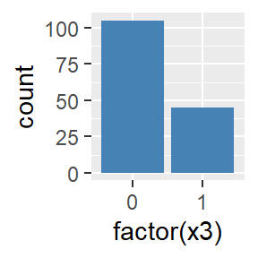

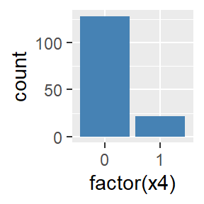

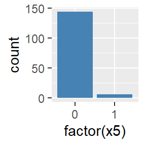

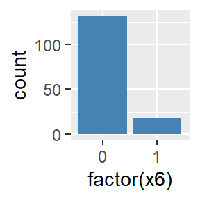

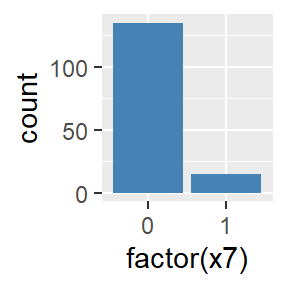

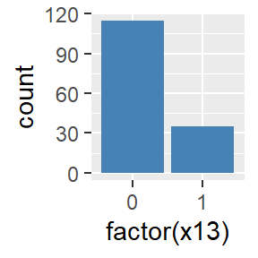

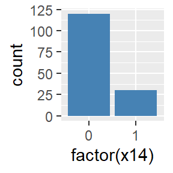

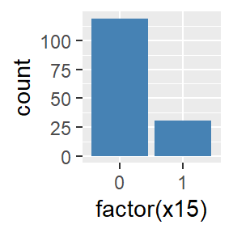

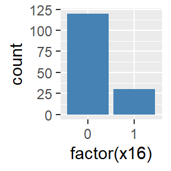

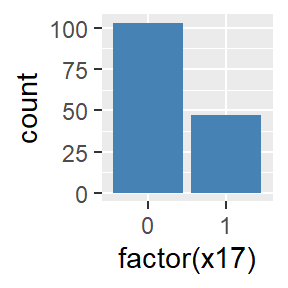

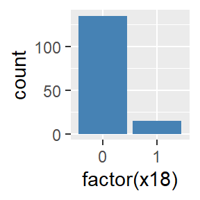

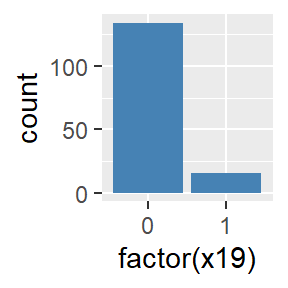

[6 more figures not shown]

### 1.2 Distibucion variables continuas Analizando los histogramas de frecuencias de las variables continuas se identifican casos de variables que las observaciones están concentradas en un rango reducido como por ejemplo las variables: x10, x12, x22, x23 o x24. Sólo las variables “y” y x8 tiene una distribución de frecuencia que se asemeja a una distribución normal.

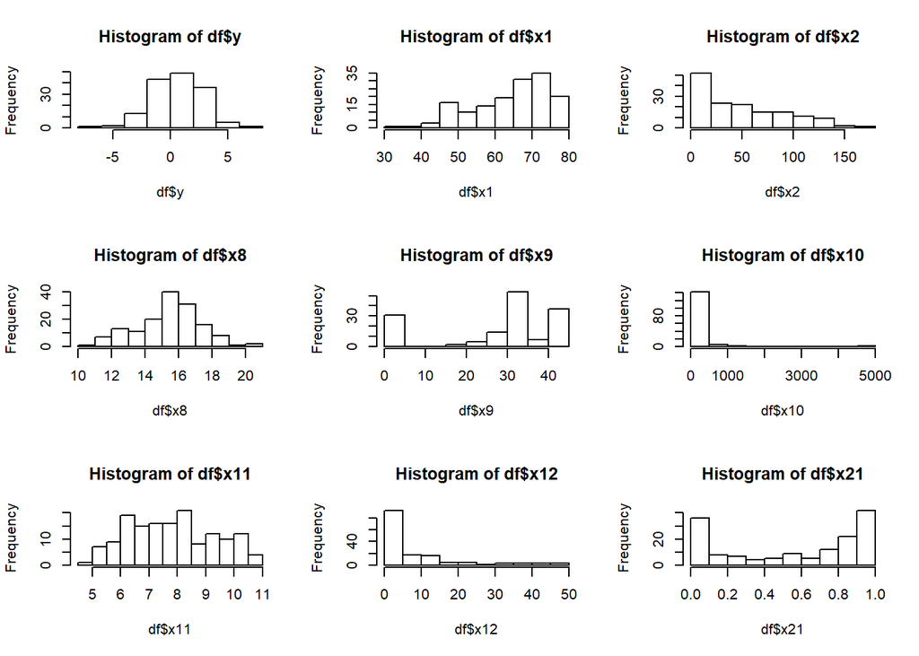

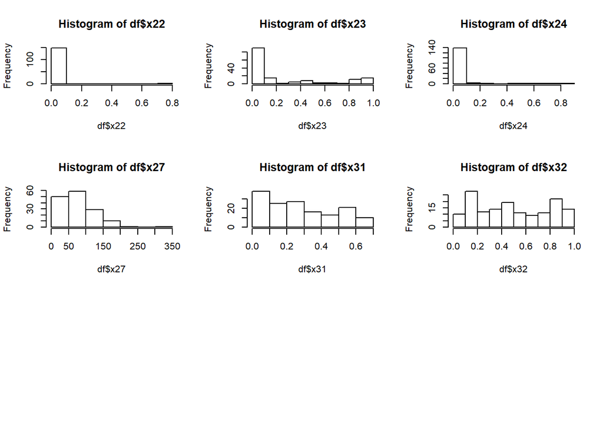

# 2. Validación de Supuestos de una Regresión Lineal Antes de poder iniciar con la selección de variables y la identificación de los posibles modelos de regresión lineal, se debe verificar el cumplimiento de los siguiente supuestos:

- Linealidad de los datos:
- Normalidad: Los valores residuales de la regresión tiene una distribución normal.
- Homoscedasticidad: la varianza de las variables predictoras es constante a lo largo de las observaciones.
- Identificación de datos influyentes
- Multicollinearity: No debe existir multicolinealidad entre los datos.

### 2.1 Linealidad de los Datos

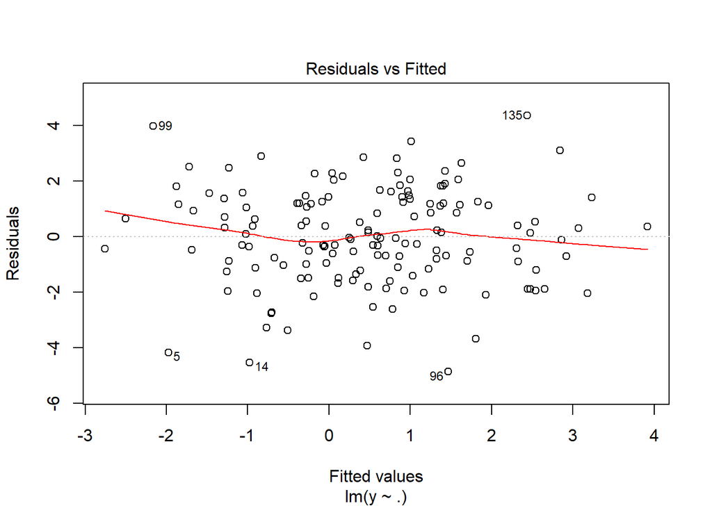

```r
model_lm_all <- lm(y~.,data=df)
plot(model_lm_all, which=1, id.n=5)
```

Del gráfico de los Valores Residuales vs Valores Pronósticados (*fittes values*), no se identifica algún patrón de la distribución de las observaciones. De otra parte, la línea roja No es completamente horizontal sobre el valor de cero, entre el rango de los valores de -2 y -1 del eje de valores pronósticados, la línea roja está ligeramente por encima con una pendiente negativa, y entre el rango de los valores de 2 y 4 del eje de valores pronósticados, la línea roja está ligeramente por debajo del cero y con una pendiente negativa. Luego se concluye que cumple con el supuesto de Linealidad de los datos.

### 2.2 Normalidad de los datos

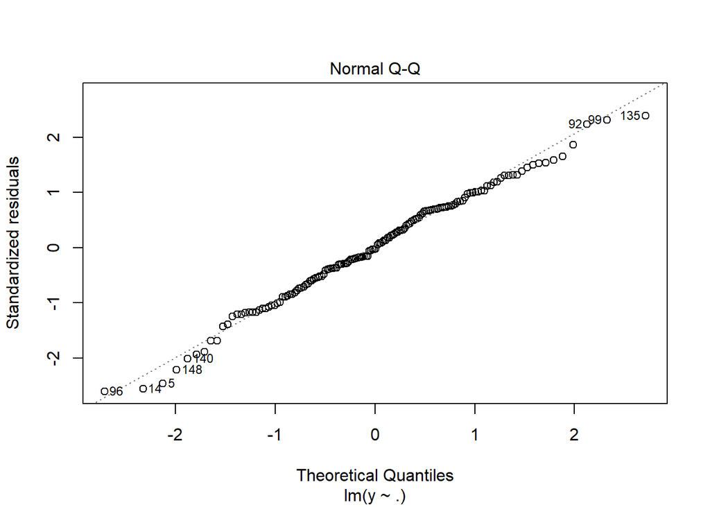

```r
restud_Model_all<-round(rstudent(model_lm_all),4)
testShapWilk<-shapiro.test(restud_Model_all)
plot(model_lm_all, which=2, id.n=8)
```

### 2.3 Homoscedasticidad

```r
# Falta incluir el test de Homoscedasticidad
anova(model_lm_all)
```

```
## Analysis of Variance Table
##
## Response: y
##            Df Sum Sq Mean Sq F value     Pr(>F)
## x1          1   7.10   7.099  1.8763    0.17338
## x2          1   2.73   2.728  0.7212    0.39750
## x3          1   8.18   8.176  2.1611    0.14423
## x4          1   0.00   0.001  0.0004    0.98491
## x5          1   1.87   1.868  0.4937    0.48367
## x6          1   0.32   0.316  0.0835    0.77316
## x7          1   4.17   4.169  1.1019    0.29600
## x8          1   0.24   0.238  0.0628    0.80254
## x9          1   5.57   5.572  1.4729    0.22733
## x10         1  12.77  12.768  3.3749    0.06873 .
## x11         1   0.46   0.465  0.1229    0.72655
## x12         1  11.63  11.629  3.0738    0.08218 .
## x13         1  24.98  24.981  6.6032    0.01144 *
## x14         1   2.73   2.733  0.7224    0.39710
## x15         1   1.72   1.716  0.4535    0.50200
## x16         1   0.13   0.134  0.0355    0.85093
## x17         1   0.00   0.002  0.0005    0.98279
## x18         1   1.86   1.855  0.4904    0.48516
## x19         1  17.77  17.768  4.6965    0.03225 *
## x20         1  17.82  17.815  4.7090    0.03203 *
## x21         1  12.31  12.306  3.2527    0.07388 .
## x22         1   2.16   2.164  0.5720    0.45099
## x23         1  79.41  79.409 20.9898 0.00001162 ***
## x24         1   0.47   0.468  0.1238    0.72556
## x25         1  12.96  12.955  3.4244    0.06676 .
## x26         1   1.75   1.747  0.4617    0.49819
## x27         1   0.17   0.167  0.0441    0.83406
## x28         1   0.44   0.444  0.1174    0.73248
## x29         1   1.48   1.481  0.3914    0.53277
## x30         1   1.66   1.659  0.4385    0.50917
## x31         1  16.94  16.937  4.4769    0.03648 *
## x32         1   0.31   0.315  0.0832    0.77346
## Residuals 117 442.64   3.783
## ---
## Signif. codes:  0 '***' 0.001 '**' 0.01 '*' 0.05 '.' 0.1 ' ' 1
```

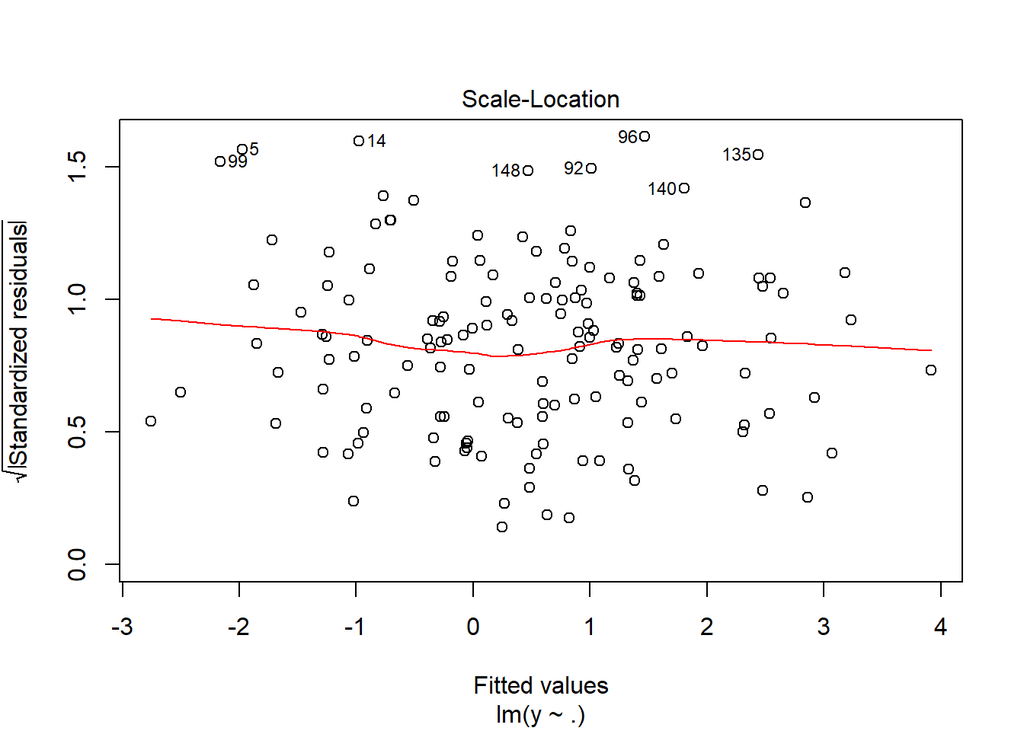

```r
plot(model_lm_all, which=3, id.n=8)
```

### 2.4. Identificación de Datos Influyentes

Previo a la identificación de los valores influyentes, se va identificar los valores atípicos (*outliers*)

#### Identifación de valores atípicos

Analizando la distribución de todos los datos con los valores mínimos, máximos y la media. Se identifica algunas anomalias entre los valores extremos y el percentil 75, por lo tanto se procede a visualizar un boxplot para identidicar la distribucion de estas variables. Por el momento no se realiazaría ninguna acción sobre estas variables.

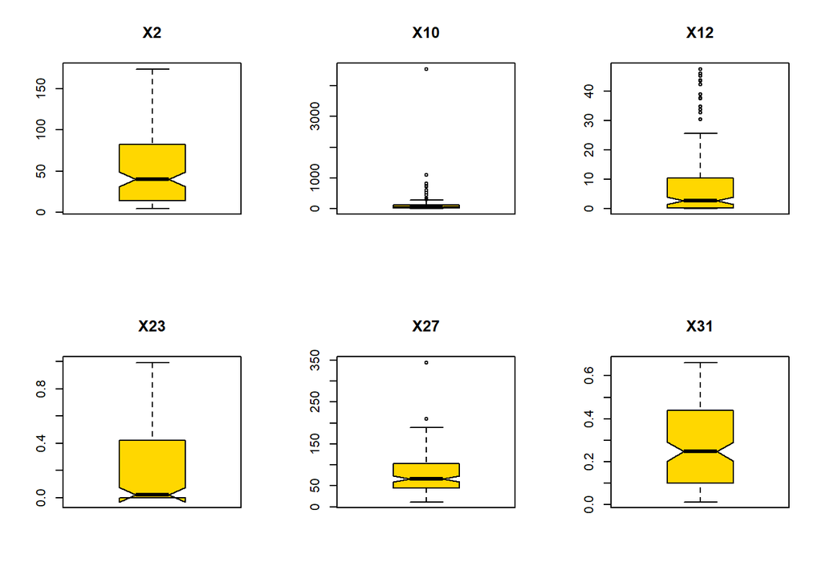

```r
outlierX10<-outliers::outlier(df$x10)
outlierX27<-outliers::outlier(df$x27)
df[df$x10==outlierX10 | df$x27==outlierX27,c("x10","x27")]
```

```
##          x10    x27
## 138 4547.958 344.83
```

Coincidencialmente se identifica que los outliers de las variables x10 y x27 corresponden a la observación 138. Sin embargo, antes de tomar una decisión sobre eliminar o no está observación se procederá a validar si es una observación influyente.

Se considera conveniente identificar si existen valores extremos que tengan una influencia significativa en el cálculo de los valores de la regresión 2, para lo que se utilizará la métrica denominada Distancia de *Cook*, que se calcula removiendo del modelo el i-ésimo dato y calculando la regresión, sumando el cambio de todos los valores del modelo de regresión dado que se se removió el el i-ésimo dato. La formula de la distancia de Cook es: $D_i=\frac{\sum_{j=1}^n(\hat{Y}_j - \hat{Y}_{j(i)})^2}{(p+1)\hat{σ}^2}$

Teniendo como referencia del punto de corte la formula $\frac{4}{n-p-1}$, siendo *n* el número de observaciones, *p* el número de variables predictoras.

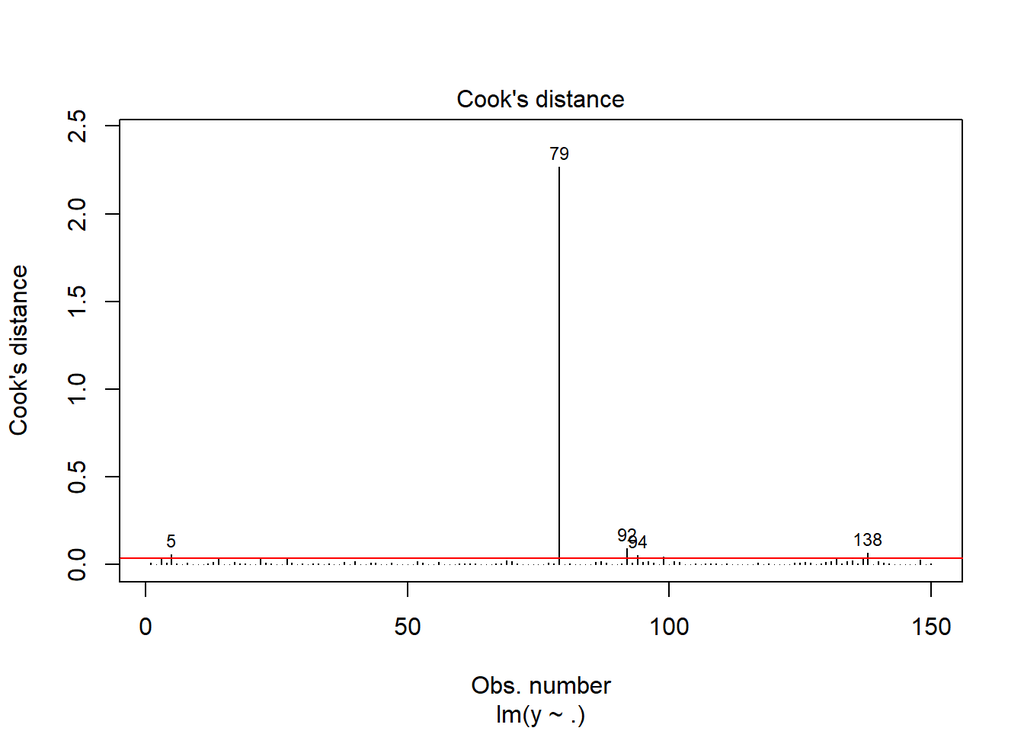

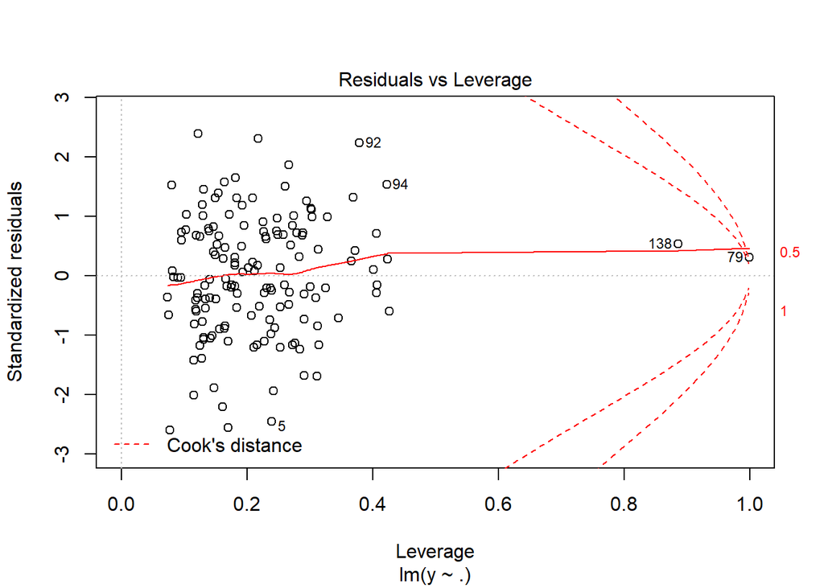

Al analizar la gráfica de la distancia de Cook vs Observaciones, claramente se identifica que el registro 79 tiene una distancia de *Cook* de 2.27 que considerablemente supera el valor de la línea roja o punto de corte que es de0.03. Lo que se ratifica con la gráfica de los Residuales vs Influencia (*Leverage*), en la que se identifica que la observación 79 está superando (a la derecha) la línea roja discontinua que delimita la distancia de *Cook*,lo que indica que corresponde a un valor extremo que tiene una inflencia significativa en el resultado del cálculo de la regresión,

De acuerdo con esto la recomendación es eliminar del conjunto de datos la observación 79 y a varificar como queda la distribución de la distancia de Cook de las restantes observaciones.

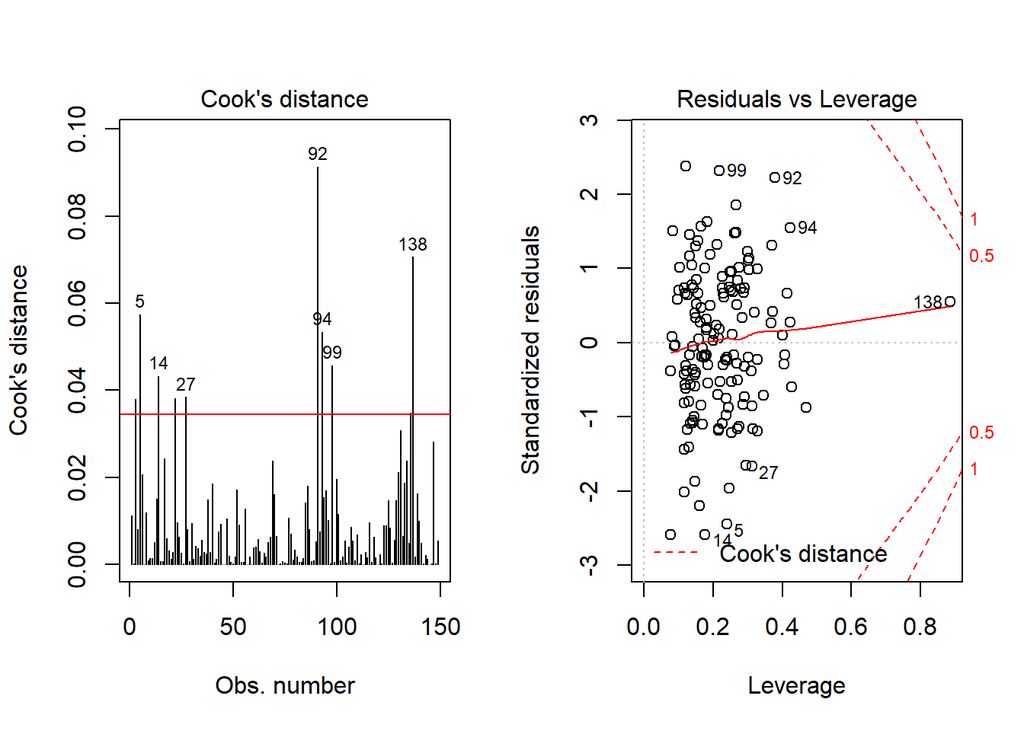

Habiendo retirado la observación 79, en la imagen de la distancia de Cook vs Observacionesse aprecian las observaciones 5, 14, 27, 92, 94, 99, y 138, están por encima del limite del punto corte. Sin embargo, en la gráfica de los Residuales vs Influencia, estos puntos se identifica que están a la izquierda de la linea roja puntuada que corresponde al limite de la Diastancia de Cook, por lo que no se considera que sean una observación influyente, por lo que no es necesario retiralo del conjunto de observaciones.

### 2.5 Detectando Multicolinealidad

A continuación se procederá a verificar si existe colinealidad entre dos o más variables predictoras, para lo que se calculará el Factor de Inflación de Varianza (VIF)2, que identifica cómo la varianza de los coeficientes de la regresión son inflados debido a multicolinealidad del modelo. $VIF=\frac{1}{Tol}=\frac{1}{1-R^2}$

El menor valor de VIF es uno (1) que indica ausencia de multicolinealidad. La recomendación es que los valores de VIF que sean mayores de 5 o 10 es un indicio de multicolinealidad, algunas fuentes mencionan que para modelos débiles, a partir de un VIF de 2.5 puede ser un indicio de multicolinealidad y otras afirman que un valor de VIF inferior a 4 se consdiera bueno para el modelo, por lo que se establecerá como valor de referencia de multicolinealidad un valor de 5.

```
## c("x1", "x2", "x11", "x17", "x21", "x23", "x31", "x32")
```

|  | VIF | collinearity |
| --- | --- | --- |
| x1 | 16.62 | True |
| x2 | 12.96 | True |
| x11 | 6.43 | True |
| x17 | 6.76 | True |
| x21 | 11.91 | True |
| x23 | 9.11 | True |
| x31 | 26.40 | True |
| x32 | 26.36 | True |

Después de realizar el cálculo del VIF se identifica que las siguientes variables x1, x2, x11, x17, x21, x23, x31, x32 tienen un valor de VIF superior a 5, por lo que se procederá a calcular cuál es la correlación entre estas variables, dejando solamente las que tengan un valor superior a 0.5.

|  | x1 | x2 | x11 | x17 | x21 | x23 | x31 | x32 |
| --- | --- | --- | --- | --- | --- | --- | --- | --- |
| x1 |  | 0.94 | 0.832 | 0.721 | 0.32 |  |  |  |
| x2 | 0.94 |  | 0.823 | 0.672 | 0.383 | 0.326 |  |  |
| x11 | 0.832 | 0.823 |  | 0.533 | 0.362 |  |  |  |
| x17 | 0.721 | 0.672 | 0.533 |  |  |  |  |  |
| x21 | 0.32 | 0.383 | 0.362 |  |  | 0.775 | 0.327 |  |
| x23 |  | 0.326 |  |  | 0.775 |  |  |  |
| x31 |  |  |  |  | 0.327 |  |  | 0.973 |
| x32 |  |  |  |  |  |  | 0.973 |  |

|  | VIF | collinearity |
| --- | --- | --- |
| x1 | 3.44 | False |
| x3 | 3.39 | False |
| x4 | 2.03 | False |
| x5 | 1.42 | False |
| x6 | 2.81 | False |
| x7 | 1.52 | False |
| x8 | 3.22 | False |
| x9 | 1.67 | False |
| x10 | 1.92 | False |
| x12 | 2.01 | False |
| x13 | 2.40 | False |
| x14 | 1.54 | False |
| x15 | 2.31 | False |
| x16 | 2.50 | False |
| x18 | 1.91 | False |
| x19 | 2.24 | False |
| x20 | 1.49 | False |
| x22 | 1.31 | False |
| x23 | 2.60 | False |
| x24 | 1.61 | False |
| x25 | 2.33 | False |
| x26 | 2.87 | False |
| x27 | 3.41 | False |
| x28 | 1.35 | False |
| x29 | 1.93 | False |
| x30 | 2.92 | False |
| x31 | 1.53 | False |

Luego se detecta que entre las variables que se dejaron en el conjunto de datos, ya NO existen multicolinealidad.

### 2.6 Resumen de Resultados de Intervenciones

Antes de avanzar en la evaluación de modelos, se considera conveniente realizar una evaluación comparativa de los modelos de regresión lineal simple que se han establecido hasta el momento con las exclusiones de datos influyentes y variables que presentan multicolinealidad, lo que nos puede servir como base o referencia.

|  | R² | R².Ajustado | MSE | BIC | Accuracy |
| --- | --- | --- | --- | --- | --- |
| Todas las variables | 0.3629 | 0.1886 | 2.9509 | 327.67 | 0.740 |
| Sin Datos Influenciadores | 0.3634 | 0.1877 | 2.9683 | 327.24 | 0.752 |
| Sin Multicolinealidad ni dato influyente | 0.3537 | 0.2095 | 3.0134 | 304.47 | 0.752 |

De acuerdo con los valores establecidos para las métricas descritas en la anterior tabla, se identifica que el conjunto de observaciones en la que se excluyeron la observación 79 (por ser una observación influyente) y las variables (“x2”,“x11”,“x17”,“x21”,"x32) que presentaban multicolinealidad tiene el mayor valor de R² ajustado 0.2095, lo que indicaría que el modelo de regresión con este conjunto de datos, permite explicar una mayor proporcio de la variabilidad de la variable resultado $y$. Pero a la vez este conjunto de datos tiene el menor valor de BIC (*Bayesian Information Criteria*), lo que es buen indicio entre la complejidad (relacionado con la cantidad de variables) del modelo y el poder de predicción del modelo.

De otra parte, revisando la rúbrica de evaluación del modelo, en la que establece que “*La capacidad predictiva general será el error cuadratico medio(MSE) y para determinar la capacidad predictiva específica será la correcta clasificación de los valores inferiores y superiores a -1 para la variable continua.*” Se identifica que el conjunto de datos que no tiene el dato influyente ni las variables que presentaban multicolinealidad tiene un alto MSE 3.0134, lo cual no correspondería el ideal de la capacidad predictiva, pero si tiene una mejor capacidad predictiva específica 0.752.

Por lo anterior, se continuará evaluando modelos utilizando este conjunto de datos que no tiene el dato influyente ni las variables que presentaban multicolinealidad.

# 3. Identificación de Modelos que Mejoren la Predicción

Previo a la identificación de modelos, se procederá a aplicar la validación cruzada en el que se dividen las observaciones del conjunto que no tiene el dato influyente ni las variables que presentaban multicolinealidad, en dos subconjuntos, uno para entrenamiento de los modelos con el 70% de las observaciones, otro subconjunto para evaluar o probar el desempeño de cada modelo con el 30% de las observaciones.

Luego de esta división de las observaciones se tiene que el subconjunto de entrenamiento tiene 105 observaciones y el subconjunto con los datos de prueba tiene 44 observaciones.

### 3.1 Métodos Frecuentistas

#### 3.1.1 Regresion lineal utilizando el Método Stepwise

Se parte como modelo inicial el modelo base con todas las variables para ir corriendo diferentes modelos para determinar cual es el mejor, esta tecnica va comparando el modelo base quitando o agregando las variables sobre el espacio de los parámetros. La métrica utilizada para seleccionar el mejor modelo en este ejercicio fue $BIC=\ln{n} - 2\ln{\hat{L}}$, donde: $\hat{L}= p(x|\hat{\theta},M)$ es el valor maximizado de la probabilidad del modelo y $\hat{\theta}$ los parámetros que maximizan la función de verosimilitud 1.

```r
model_lm_entrenamiento <- lm(y~.,data=dtConEntrenamiento)
numObser_entrenamiento <- nrow(dtConEntrenamiento)
modelBIC<- stepAIC(model_lm_entrenamiento, direction="both",k=log(numObser_entrenamiento))
listcoeff<- summary(modelBIC)$coefficients[,1]
summary(modelBIC)
listvarAIC<- names(summary(modelBIC)$coefficients[,1])[-1]
predictAICPrueba <-predict(modelBIC, dtConPrueba)
accuracyAIC<-round(accuracy_lm(dtConPrueba$y, predictAICPrueba),digits = 2)
```

[output not shown]

#### 3.1.2 Regresion lineal utilizando el Método Ridge

La Regresión Ridge es una metodologia de regularizacion, que busca resolver problemas mal planteados. En este ejercicio sera utilizada para seleccionar variables en regresiones lineales con un gran numero de parametros.
$$\begin{equation}
\widehat\beta_{Ridge} = (X'X+\lambda I)^{-1}(X'y)
\end{equation}$$
donde $\lambda$ es el parametro de penalización, esta funcion no solo minimiza la funcion de los residuos al cuadrado, si no tambien la estimacion de los parametros reduciendolos a 0.2

```
## 28 x 1 sparse Matrix of class "dgCMatrix"
##                       s0
## (Intercept)  0.462037389
## x1           0.075266208
## x3          -0.056598274
## x4           0.034971006
## x5          -0.005329931
## x6           0.040943947
## x7           0.003792928
## x8           0.043702681
## x9          -0.004977494
## x10         -0.019275257
## x12          0.057723851
## x13         -0.119595605
## x14         -0.071499183
## x15         -0.032934427
## x16         -0.034650474
## x18         -0.043222410
## x19         -0.037016771
## x20          0.088271816
## x22         -0.021067370
## x23          0.231896261
## x24         -0.123679718
## x25          0.163824934
## x26         -0.052263991
## x27          0.015671250
## x28         -0.004899795
## x29          0.099851751
## x30          0.011023035
## x31         -0.163664734
```

El resultado de correr el método de Ridge Regression, da como reultado un $\lambda=$ 4.329 se identifica las variables seleccionadas en el que sería el mejor modelo son: x1, x3, x4, x5, x6, x7, x8, x9, x10, x12, x13, x14, x15, x16, x18, x19, x20, x22, x23, x24, x25, x26, x27, x28, x29, x30, x31 y que la precisión es de 0.75

#### 3.1.3 Regresion lineal utilizando el Método Lasso

La Regresión Lasso es una metodologia, para seleccion de variables y resolver problemas de regularizacion. En este ejercicio sera utilizada para minimizar la cantidad de parametros de una regresión, que permitan explicar mejor el modelo.
$$\begin{equation}
\beta^* = \min\limits_{\beta \in \mathbb{R}^p} \sum_{i=1}^n \left[y_i- x_i^{'}\beta_i \right]^2 + \lambda \sum_{j=1}^p \mid \beta_j \mid
\end{equation}$$
donde $\lambda$ es el parametro de penalización, esta funcion no solo minimiza la funcion de los residuos al cuadrado, si no tambien la estimación de los parametros reduciendolos a 0. La diferencia entre Lasso y Ridge es la funcion de penalización de los parametros.4

```
## 28 x 1 sparse Matrix of class "dgCMatrix"
##                      s0
## (Intercept)  0.46203739
## x1           .
## x3           .
## x4           .
## x5           .
## x6           .
## x7           .
## x8           .
## x9           .
## x10          .
## x12          .
## x13         -0.06030940
## x14          .
## x15          .
## x16          .
## x18          .
## x19          .
## x20          .
## x22          .
## x23          0.47926980
## x24         -0.07188929
## x25          0.28710330
## x26          .
## x27          .
## x28          .
## x29          .
## x30          .
## x31         -0.27965111
```

El resultado de correr el método de Lasso Regression, da como reultado un $\lambda=$ 0.264 se identifica las variables seleccionadas en el que sería el mejor modelo son: x13, x23, x24, x25, x31 y que la precisión es de 0.75

#### 3.1.4 Regresion lineal utilizando el Método Elastic Net

La metodo de Regresion Elastic Net la cual retiene las ventajas de las metodologias Lasso y Ridge, para la seleccion de variables y resolver problemas de regularización y resolver las limitaciones de seleccionar grupos de variables correlacionadas o datos con alta multicolinealidad.
$$\begin{equation}
\hat \beta^{Elastic} = arg\min\limits_{\beta}(\Vert {y-X\beta} \Vert^2 +\lambda_2 \Vert \beta \Vert^2 + \lambda_1 \Vert \beta \Vert_1 )
\end{equation}$$
donde $\lambda_1, \lambda_2$, son los coeficientes de penalización de la función para los metodos Lasso y Ridge regression.4

```
## 28 x 1 sparse Matrix of class "dgCMatrix"
##                       s0
## (Intercept)  0.462037389
## x1           0.094524507
## x3           .
## x4           .
## x5           .
## x6           0.034866600
## x7           .
## x8           .
## x9           .
## x10          .
## x12          .
## x13         -0.239315791
## x14         -0.060491254
## x15          .
## x16          .
## x18          .
## x19          .
## x20          0.163722785
## x22          .
## x23          0.562755091
## x24         -0.118605826
## x25          0.357584302
## x26          .
## x27          .
## x28          .
## x29          0.007211157
## x30          .
## x31         -0.333896086
```

El resultado de correr el método de Elastic Regression, da como reultado un $\lambda=$ 0.302 y $\alpha=$ 0.5 se identifica las variables seleccionadas en el que sería el mejor modelo son: x1, x6, x13, x14, x20, x23, x24, x25, x29, x31 y que la precisión es de 0.77

### 3.2 Enfoques Bayesianos

#### 3.2.1 Promedio del Modelo Bayesiano

Utilizando Bayesian Model Averaging (BMA) es una metodología bayesiana que utiliza una búsqueda estocástica que compara diferentes modelos por su probabilidad aposteriori5, donde propusieron un enfoque de Markov Chain Monte Carlo que se aproxima directamente a la solución exacta, lo que lleva aproxima la respuesta sin tener que calcular $2^p$ modelos diferentes, ya que los procedimientos comunes generalmente requieren mucho tiempo de cómputo para hacer una búsqueda exhaustiva.

Sea $M= \{M_1,M_2, \dotsc,M_{2^k}\}$ el conjunto de todos los modelos posibles, donde cada uno de ellos depende de un conjunto de parámetros $\alpha_j$ $\forall j \in 1,\dotsc,2^k$, $k$ es el número de regresores posibles y $y$ es la variable dependiente, la probabilidad de modelo posterior se define como:
$$\begin{equation}
P(M_j \mid y, M)=\frac{P(y \mid M_j)\pi(M_j)}{\sum_{i=1}^{m}P(y \mid M_i)\pi(M_i)} \hspace{5mm} \forall j=1,2,\dotsc,m
\end{equation}$$

donde,
$$\begin{equation}
P(y \mid M_j)=\int ...\int P(y\mid \alpha_j, \hspace{2mm} M_j)\pi(\alpha_j \mid M_j ) d \alpha_j \hspace{5mm} \forall j=1,2,\dotsc,m
\end{equation}$$

La probabilidad integrada del modelo $M_j$, $\alpha_j$ es el vector de parámetros del modelo $M_j$, $\pi(\alpha_j \mid M_j )$ es la prior de los parámetros bajo $M_j$, $P(y\mid\alpha_j,M_j)$ es la probabilidad y $\pi(M_j)$ es la probabilidad previa del $M_j$ sea el mejor modelo.

```
##
## Call:
## bicreg(x = dtDatNoCollinearity[, -1], y = dtDatNoCollinearity[,     1], strict = TRUE, maxCol = 33, nbest = 500)
##
##
##   5  models were selected
##  Best  5  models (cumulative posterior probability =  1 ):
##
##            p!=0    EV        SD         model 1     model 2     model 3
## Intercept  100.0  -1.540791  1.5574706   -1.934141   -2.040106    0.971998
## x1           0.0   0.000000  0.0000000       .           .           .
## x3           0.0   0.000000  0.0000000       .           .           .
## x4           0.0   0.000000  0.0000000       .           .           .
## x5           0.0   0.000000  0.0000000       .           .           .
## x6           0.0   0.000000  0.0000000       .           .           .
## x7           0.0   0.000000  0.0000000       .           .           .
## x8           0.0   0.000000  0.0000000       .           .           .
## x9           0.0   0.000000  0.0000000       .           .           .
## x10         87.4   0.001155  0.0005906    0.001352    0.001147    0.001410
## x12          0.0   0.000000  0.0000000       .           .           .
## x13         87.4  -1.174083  0.6221707   -1.396014   -0.945985   -1.590878
## x14          0.0   0.000000  0.0000000       .           .           .
## x15          0.0   0.000000  0.0000000       .           .           .
## x16          0.0   0.000000  0.0000000       .           .           .
## x18          0.0   0.000000  0.0000000       .           .           .
## x19          0.0   0.000000  0.0000000       .           .           .
## x20         69.8   1.643999  1.2968395    2.332319       .        2.449528
## x22          0.0   0.000000  0.0000000       .           .           .
## x23        100.0   1.625304  0.4568944    1.604504    1.516767    1.742140
## x24          0.0   0.000000  0.0000000       .           .           .
## x25         82.7   0.409460  0.2474406    0.477276    0.501109       .
## x26          0.0   0.000000  0.0000000       .           .           .
## x27          0.0   0.000000  0.0000000       .           .           .
## x28          0.0   0.000000  0.0000000       .           .           .
## x29          0.0   0.000000  0.0000000       .           .           .
## x30          0.0   0.000000  0.0000000       .           .           .
## x31        100.0  -3.290523  0.8566564   -3.422898   -3.452507   -2.927694
##
## nVar                                        6           5           5
## r2                                        0.295       0.257       0.257
```

[output cut: 21 more lines]

```
## x22             .           .
## x23          1.702930    1.656998
## x24             .           .
## x25          0.566221       .
## x26             .           .
## x27             .           .
## x28             .           .
## x29             .           .
## x30             .           .
## x31         -3.016018   -2.932833
##
## nVar           3           4
## r2           0.204       0.216
## BIC        -18.994651  -16.180104
## post prob    0.126       0.031
```

##### Comportamiento de las variables con BMA

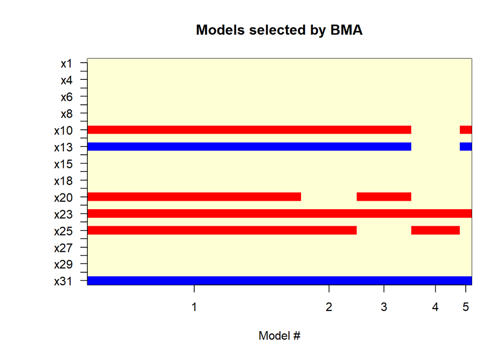

```
##
## Call:
## lm(formula = y ~ x10 + x13 + x20 + x23 + x25 + x31, data = dtConEntrenamiento)
##
## Residuals:
##     Min      1Q  Median      3Q     Max
## -4.5856 -1.2671 -0.0083  1.3812  4.3695
##
## Coefficients:
##               Estimate Std. Error t value Pr(>|t|)
## (Intercept) -2.6421587  1.3133633  -2.012 0.046992 *
## x10          0.0003925  0.0013703   0.286 0.775163
## x13         -1.2513107  0.6135148  -2.040 0.044084 *
## x20          2.2586026  1.0469245   2.157 0.033422 *
## x23          1.9837755  0.5648910   3.512 0.000675 ***
## x25          0.5774322  0.2103344   2.745 0.007193 **
## x31         -3.2738920  1.0323265  -3.171 0.002026 **
## ---
## Signif. codes:  0 '***' 0.001 '**' 0.01 '*' 0.05 '.' 0.1 ' ' 1
##
## Residual standard error: 1.909 on 98 degrees of freedom
## Multiple R-squared:  0.2999, Adjusted R-squared:  0.2571
## F-statistic: 6.998 on 6 and 98 DF,  p-value: 0.000003248
```

El resultado de utilizar BMA para la selección de variables, da como reultado del modelo se identifica las variables seleccionadas en el que sería el mejor modelo son: x10, x13, x20, x23, x25, x31 y la precisión es de 0.7

# 4. Resumen de Resultados

A continuación se presenta el resumen de los resultados obtenidos con los diferentes métodos.

|  | Núm.Variables | MSE | Accuracy | Efect.por.Variable |
| --- | --- | --- | --- | --- |
| Stepwise con BIC | 5 | 3.4053 | 0.64 | 0.128 |
| Ridge | 27 | 3.8785 | 0.75 | 0.028 |
| Lasso | 5 | 3.7173 | 0.75 | 0.150 |
| Elastic Net | 10 | 3.6244 | 0.77 | 0.077 |
| BMA | 6 | 3.5574 | 0.70 | 0.117 |

Guardar el modelo seleccionado

```r
# Guardar Base Modelo Seleccionado
lm_bma<-lm(y~x10+x13+x20+x23+x25+x31,data=dtDatNoCollinearity)
save(lm_bma, file = "ModelContinous.RData")
```

## Referencias

[1]Burnham, K. P., & Anderson, D. R. (2004). Multimodel inference: understanding AIC and BIC in model selection. Sociological methods & research, 33(2), 261-304.  
[2]Friedman, J., Hastie, T., & Tibshirani, R. (2010). Regularization paths for generalized linear models via coordinate descent. Journal of statistical software, 33(1), 1.  
[3]Tibshirani, R. (1996). Regression shrinkage and selection via the lasso. Journal of Royal Statistical Society:Series B (methodology), 67(1): 91-108.  
[4] Zou, H. and Hastie, T. (2005). Regularization and variable selection via the elastic net. Journal of Royal Statistical Society: Series B (methodology), 67(2): 301-320.  
[5] Raftery, A. E., Madigan, D., & Hoeting, J. A. (1997). Bayesian model averaging for linear regression models. Journal of the American Statistical Association, 92(437), 179-191.